# Linear Mixed Effects Model

## Reading

This set of notes is based on Hoff Chapter 6.

## Linear Mixed Effects Model

Linear mixed effects models extend linear models to allow random effects, and in many ways overlap with hierarchical models. We introduce the framework of the linear mixed effects model in the context of longitudinal data.

## Related Models

- mixed models
- mixed effects models
- random effects models
- two-stage models
- hierarchical models
- multilevel models
- Laird and Ware models

## Mixed Effects Models for Longitudinal Data

In mixed effects models, the response depends on population parameters $\beta$ as well as subject-specific random effects. These models are especially convenient when there are no set times for observation of outcomes in a longitudinal study, which makes it challenging to estimate a covariance matrix across time in a multivariate setting.

NOTE: In the setting of longitudinal data, indices are typically the opposite of those in the multilevel modeling setting. That is, $Y_{ij}$ denotes the response at time $j$ for subject $i$. This is standard notation in the context of mixed effects models.

Because of missing data, differential timing, and other factors, $\text{Var}(Y_{ij})$ may depend on $i$ and $j$. Mixed effects models handle such structures naturally.

In addition, using random effects in the model is one way to model the covariance structure as a function of time.

## Longitudinal Versus Cross-Sectional Data

In a *longitudinal* study, subjects are measured repeatedly over time. We can think of these as multilevel data, with repeated measures on each individual subject (so the subject is the group).

In a *cross-sectional* study, a single outcome is measured for each individual, though individuals may belong to different cohorts.

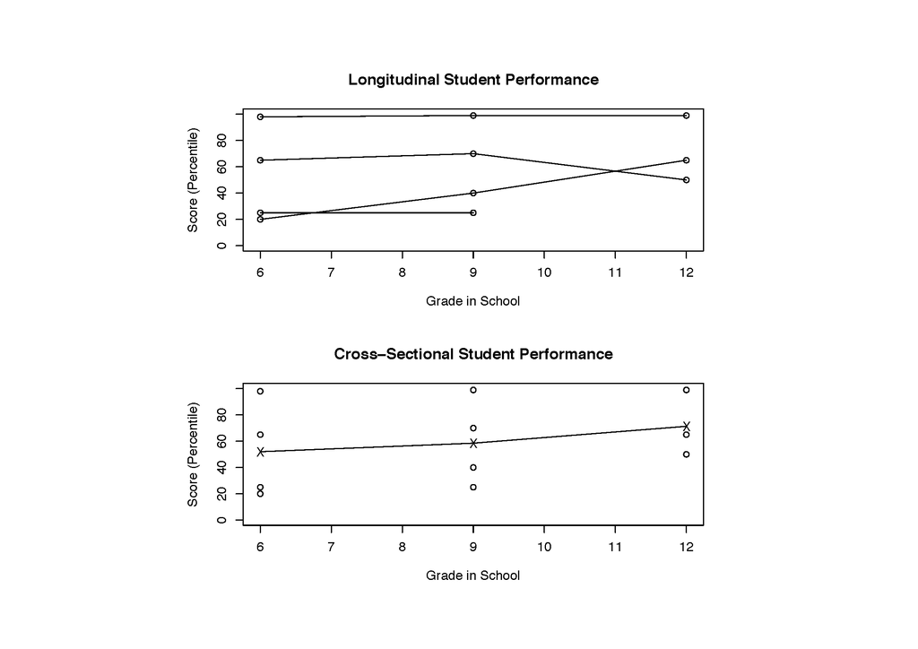

A key feature of the longitudinal design above is that one cohort of students, recruited in 6th grade, is followed until 12th grade (except in the case of *dropouts*). The cross-sectional study can be completed at one point in time, with the 6th, 9th, and 12th grade cohorts tested concurrently.

In the cross-sectional study depicted, it is not possible to determine whether scores in 12th grade are better because the teachers are better, students have learned more in earlier grades, the weaker students dropped out, etc. A longitudinal design gives us much more information to assess reasons for change.

In the cross-sectional design, we do not have any repeated scores from the same student. Often, all observations may be treated as independent.

In a longitudinal analysis, we can investigate

- changes over time within individuals
- differences among individuals in their response levels

Longitudinal data analysis requires special statistical methods (e.g., a multilevel model) because the observations on any one subject tend to be positively correlated.

## Orthodontics Data

Changes in the distance (measured in mm) from the center of the pituitary gland to the pterygomaxillary fissure are important in orthodontic therapy.

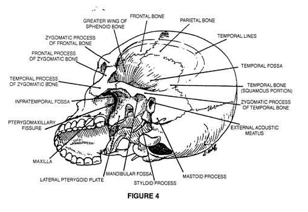

[figure not shown]

## Pothoff and Roy (1964) Study

- This distance was measured at ages 8, 10, 12, and 14 in 27 children (16 boys and 11 girls)
- Questions of interest include the following:
  - Does distance change over time?
  - What is the pattern of change?
  - Is the pattern of change different for boys and girls? How?

```r
library(lme4)
data(Orthodont,package="nlme")
head(Orthodont)
```

```
## Grouped Data: distance ~ age | Subject
##   distance age Subject  Sex
## 1     26.0   8     M01 Male
## 2     25.0  10     M01 Male
## 3     29.0  12     M01 Male
## 4     31.0  14     M01 Male
## 5     21.5   8     M02 Male
## 6     22.5  10     M02 Male
```

```r
Orthodont$Sex=relevel(Orthodont$Sex,ref="Female")
```

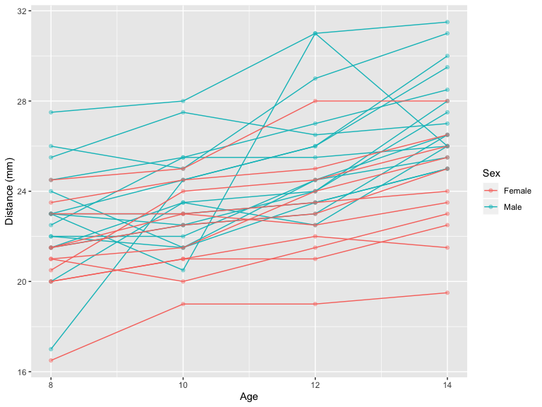

What kind of model might be appropriate?

## Modeling Growth

We might consider a linear model given by
$$Y_{ij}=\beta_{0i}+\beta_{1i}t_{ij}+\varepsilon_{ij},$$
where $i$ indexes the child and $j$ indexes time $j=1,2,3,4$, with in this case, $t_{ij}=t_j$ as each child was measured at $t_1=8$, $t_2=10$, $t_3=12$, and $t_4=14$ years.

Recall our research questions:

- Does distance change over time? (main effect of age)
- What is the pattern of change? (linear age, categorical?)
- Is the pattern of change different for boys and girls? How? (age by gender interaction)

Recall our research questions:

- Does distance change over time? (main effect of age)
- What is the pattern of change? (assuming linear age for now)
- Is the pattern of change different for boys and girls? How? (age by gender interaction)

$$Y_{ij}=\beta_{0i}+\beta_{1i}t_{j}+\varepsilon_{ij}$$
$$\beta_{0i}=\alpha_{00}+\alpha_{01}I(male)_i+b_{0i}$$
$$\beta_{1i}=\alpha_{10}+\alpha_{11}I(male)_i+b_{1i}$$

Let’s consider how the framework of the linear mixed effects model can be used in this case.

## Linear Mixed Effects Model

$$Y_i=X_i\beta+Z_ib_i+\varepsilon_i$$
$$b_i \perp \varepsilon_i ~~~~~~~~ b_i \sim N_q(0,D) ~~~~~~~~ \varepsilon_i \sim N_{n_i}(0,R_i)$$

- $Y_i$ is a $n_i \times 1$ vector of outcomes for subject $i$
- $X_i$ is a $n_i \times p$ design matrix of predictor variables corresponding to each outcome measurement occasion for subject $i$
- $Z_i$ is a $n_i \times q$ design matrix corresponding to the random effects for subject $i$
- $\beta$ is a $p \times 1$ vector of regression coefficients (fixed effects)
- $b_i$ is a $q \times 1$ vector of random effects for subject $i$
- $\varepsilon_{i}$ is a $n_i \times 1$ vector of errors for subject $i$

In this model,
$$E(Y_i)=X_i\beta$$
and
$$\text{Var}(Y_i)=\text{Var}(Z_ib_i+\varepsilon_i)=Z_iDZ_i'+R_i.$$

$Z_i$ characterizes among-unit variation. When the columns of $Z_i$ are a subset of the columns of $X_i$, we can interpret $Z_ib_i$ as the difference between subject $i$’s conditional mean response trajectory and the mean response trajectory in the population (that is, $b_i$ has mean zero).

Example: in a random intercept model, $Z_i$ is a $n_i \times 1$ vector of 1’s

- The subject-specific or conditional mean of $Y_i$ given $b_i$ is $E(Y_i \mid b_i)=X_i\beta+Z_ib_i$
- The marginal or populatoin-averaged mean of $Y_i$, averaging over the distribution of random effects $b_i$ is given by $E(E(Y_i\mid b_i))=E(X_i\beta+Z_ib_i)=X_i\beta$ as $b_i$ has mean zero.

If we have only a random intercept $b_{0i}$ and $\text{Var}(b_{0i})=\tau^2$ and $\text{Var}(\varepsilon_i)=\sigma^2I$, then

$\text{Var}(Y_i)=\tau^2 Z_iZ_i'+\sigma^2I=\begin{pmatrix} \sigma^2+\tau^2 & \tau2 & \ldots & \tau^2 \\ \tau^2 & \sigma^2+\tau^2 & \ldots & \tau^2 \\ \vdots & \ldots & \ldots & \vdots \\ \tau^2 & \ldots & \ldots & \sigma^2+\tau^2 \end{pmatrix}$.

This form is called *compound symmetry* or *exchangeable* and represents the simplest possible example of a mixed effects model.

## Choices for $R_i$

The most common choice for within-subject variation, $\text{Var}(\varepsilon_i)=R_i$ is $\sigma^2I_{n_i}$. This implies that the error variance is the same at all time points and that there is no autocorrelation in the random errors. This may be appropriate if the main source of within-subject variation is measurement error.

We could, however, choose more elaborate structures for $R_i$ – for example, we may feel $R_i$ depends on the value of a covariate or that an autoregressive structure is needed (for example, observations made closer together in time may be more highly correlated than observations further apart in time). This is a distinction between standard multilevel models that typically assume $R_i=\sigma^2I_{n_i}$ and the linear mixed effects model, which allows a more general error variance.

## Example: Children Nested in Families

Consider the model

$y_{ij}=\beta_{0,i}+\beta_{1,i}x_{ij}+\varepsilon_{ij}$

$\beta_{0,i}=\beta_0+b_{0,i} ~~~ \beta_{1,i}=\beta_1+b_{1,i}$

$\left(\begin{array}{l} b_{0,i} \\ b_{1,i} \end{array}\right) \overset{iid}\sim N\left( \left(\begin{array}{l} 0 \\ 0 \end{array}\right), \left(\begin{array}{ll} \tau_{11} & \tau_{12} \\ \tau_{12} & \tau_{22} \end{array}\right)\right) \perp \varepsilon_{ij} \overset{iid}\sim N(0,\sigma^2)$

$i=1,\ldots,m$ families and $j=1,\ldots,n_i$ children within family $i$

Write this model as a linear mixed effects model of the form
$$Y_i=X_i\beta+Z_ib_i+\varepsilon_i$$
clearly specifying the elements of $Y_i$, $X_i$, $Z_i$ and $\beta$ and the distributional assumptions on $b_i$ and $\varepsilon_i$.

Derive the general form of the correlation between:

- two children in different families $i$ and $i'$, Corr$(Y_{ij},Y_{i'j'})$
- two children in the same family $i$, Corr$(Y_{ij},Y_{ij'})$

Tip: for the second part, you can either use the formula from a few slides back for $\text{Var}(Y_i)$, or you can derive from first principles as the covariance of two linear combinations of random variables.

In the dental data, the kids are all measured at age 8, 10, 12, and 14. (Really? Did they all come in for the study on their birthdays?) Probably the kids were measured within a few months of each age, and maybe some were pretty late. How can this model accommodate unequal or unbalanced measurement times?

## Choices for $D$

Var($b_i$)=$D$ could be different for different groups if there is strong evidence different treatment conditions have a nonnegligible effect on variation as well as on the mean. Typically $D$ is unstructured.

Intercepts and slopes may tend to be large or small together, so that children with steeper slopes tend to “start out” larger at birth – or the opposite may be true – perhaps small kids tend to grow faster in order to catch up. Either way, it’s generally unwise to specify $D$ as diagonal.

In a random intercepts and slopes model, we may have
$$\text{Var}(b_i)=\text{Var}\begin{pmatrix}b_{0i}\\b_{1i}\end{pmatrix}=D=\begin{pmatrix}d_{11} & d_{12} \\ d_{12} & d_{22} \end{pmatrix}.$$
$d_{11}=d_{22}$ (homogeneous variances) is generally unrealistic because the intercept is on the same measurement scale as $Y$, but the slope is on the scale of “response increment per unit change in predictor.”

So unstructured $D$ is usually the way to go.

One problem with trying to get “too fancy” in modeling $D$ and $R_i$ is that we may run into *identifiability* issues. For example, it is not possible in a frequentist model to estimate both unstructured $D$ and unstructured $R_i$ as the number of free parameters in those matrices exceeds the number of free components in the matrix $\text{Var}(Y_i)$.

For example, suppose $Y_i$ contains 4 response measures for each participant in a study, with each participant measured at the same 4 times. Cov$(Y_i)=\Sigma$ is a $4\times 4$ matrix and has $\frac{n(n+1)}{2}=10$ unique elements. How many covariance parameters would we need to estimate of we assume $R_i$ is unstructured in a model with random intercepts and slopes?

Translating our model from the multilevel formulation

$$Y_{ij}=\beta_{0i}+\beta_{1i}t_{j}+\varepsilon_{ij}$$
$$\beta_{0i}=\alpha_{00}+\alpha_{01}I(male)_i+b_{0i}$$
$$\beta_{1i}=\alpha_{10}+\alpha_{11}I(male)_i+b_{1i}$$

to a standard mixed model formulation (just rewriting and changing notation) we have
$$Y_{ij}=\beta_0+\beta_1I(\text{male})_i+\beta_2t_j+\beta_3I(\text{male})_it_j + b_{0i} + b_{1i}t_j + \varepsilon_{ij}$$
where $\begin{pmatrix} b_{0i} \\ b_{1i} \end{pmatrix} \overset{iid}\sim N\left(0,\begin{pmatrix}d_{11} & d_{12} \\ d_{12} & d_{22}\end{pmatrix}\right) \perp \varepsilon_{ij} \overset{iid}\sim N(0,\sigma^2)$. Let’s fit and interpret this model!

```r
library(lme4)
m1=lmer(distance~Sex+age+age*Sex+(1+age|Subject),data=Orthodont)
summary(m1)
```

```
## Linear mixed model fit by REML ['lmerMod']
## Formula: distance ~ Sex + age + age * Sex + (1 + age | Subject)
##    Data: Orthodont
##
## REML criterion at convergence: 432.6
##
## Scaled residuals:
##     Min      1Q  Median      3Q     Max
## -3.1694 -0.3862  0.0069  0.4454  3.8491
##
## Random effects:
##  Groups   Name        Variance Std.Dev. Corr
##  Subject  (Intercept) 5.77441  2.4030
##           age         0.03245  0.1801   -0.67
##  Residual             1.71661  1.3102
## Number of obs: 108, groups:  Subject, 27
##
## Fixed effects:
##             Estimate Std. Error t value
## (Intercept)  17.3727     1.2280  14.147
## SexMale      -1.0321     1.5953  -0.647
## age           0.4795     0.1037   4.625
## SexMale:age   0.3048     0.1347   2.263
##
## Correlation of Fixed Effects:
##             (Intr) SexMal age
## SexMale     -0.770
## age         -0.880  0.677
## SexMale:age  0.677 -0.880 -0.770
```

We’ll get more into diagnostics shortly, but here’s a start.

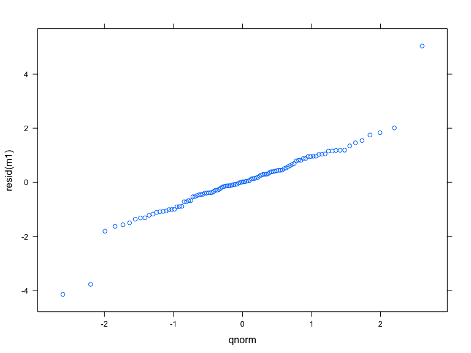

```r
library(lattice)
#basic qqplot
qqmath(resid(m1))
```

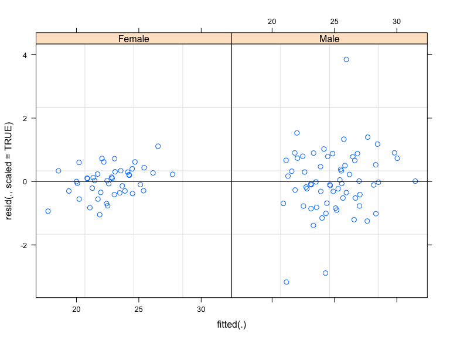

```r
#standardized residuals y-Xbeta-Zb versus fitted values by gender
#standardized by the estimate of sigma=sqrt(var(epsilon))
plot(m1,resid(.,scaled=TRUE)~fitted(.)|Sex,abline=0)
```

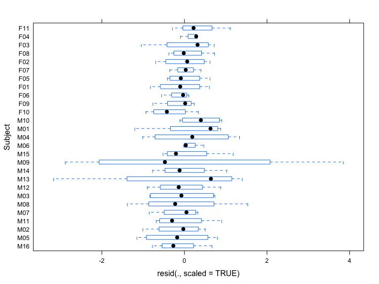

```r
## boxplots of residuals by Subject
plot(m1, Subject ~ resid(., scaled=TRUE))
```

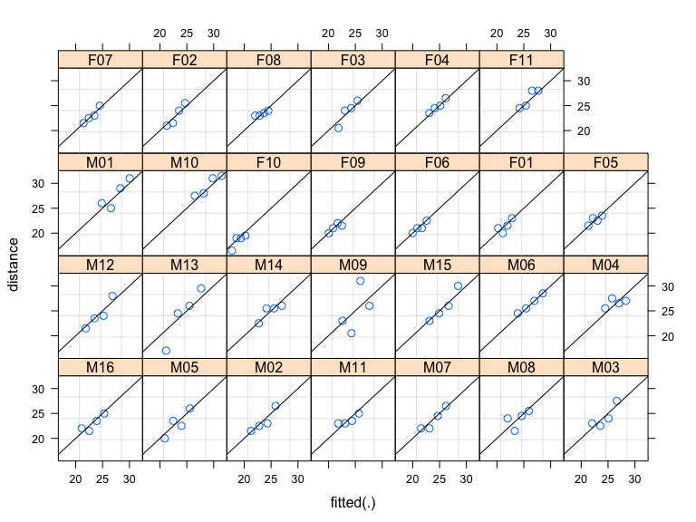

```r
## observed versus fitted values by Subject
## fitted value is X_ibeta+Z_ib_i
plot(m1, distance ~ fitted(.) | Subject, abline = c(0,1))
```

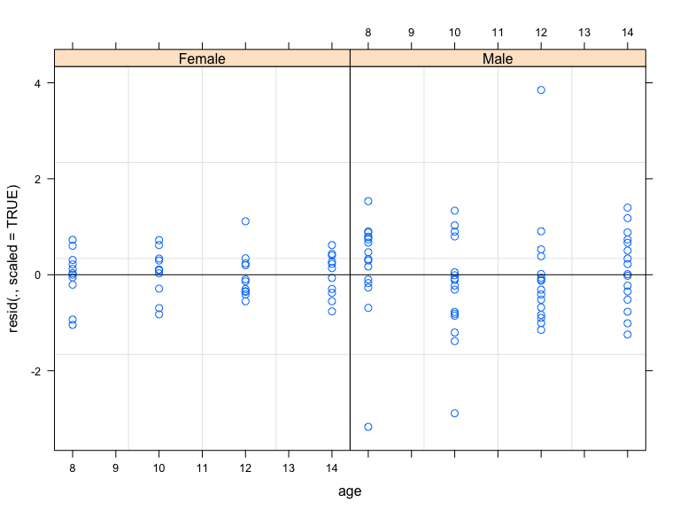

```r
## residuals by age, separated by Subject
plot(m1, resid(., scaled=TRUE) ~ age | Sex, abline = 0)
```

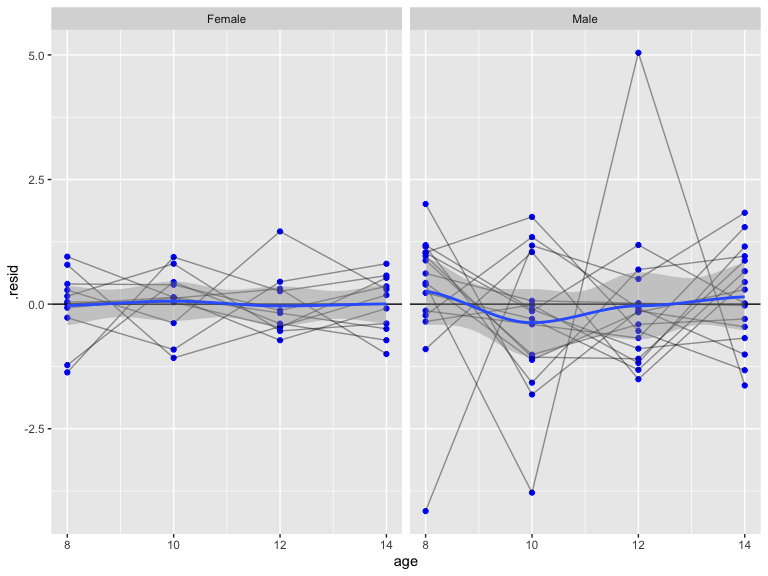

```r
library(ggplot2)
m1F <- fortify.merMod(m1)
# plot of raw residuals, use .scresid for scaled
ggplot(m1F, aes(age,.resid)) + geom_point(colour="blue") + facet_grid(.~Sex) +
        geom_hline(yintercept=0)+geom_line(aes(group=Subject),alpha=0.4)+geom_smooth(method="loess")
```

```r
## (warnings about loess are due to having only 4 unique x values)
```

## Interpreting Model Results

Note the t statistic for the interaction is a pretty good size, so we’ll keep that in the model. Let’s pick off intercepts and slopes for girls and boys along with 95% confidence intervals.

```r
#int girl, int boy, slope girl, slope boy
cmat=cbind(c(1,0,0,0),c(1,1,0,0),c(0,0,1,0),c(0,0,1,1))
girlboyintslope=t(cmat)%*%fixef(m1)
gbvcov=t(cmat)%*%vcov(m1)%*%cmat
cbind(girlboyintslope-1.96*sqrt(diag(gbvcov)),girlboyintslope,girlboyintslope+1.96*sqrt(diag(gbvcov)))
```

```
##            [,1]       [,2]       [,3]
## [1,] 14.9657585 17.3727273 19.7796960
## [2,] 14.3448719 16.3406250 18.3363781
## [3,]  0.2763005  0.4795455  0.6827904
## [4,]  0.6158532  0.7843750  0.9528968
```

```r
est=data.frame(sl = girlboyintslope[3:4,],
                 int = girlboyintslope[1:2,],
                 SEX = c('Female','Male'))
library(ggplot2)
ggplot(Orthodont, aes(x=age,y=distance,color=Sex,group=Subject)) + geom_point(alpha=0.8) + geom_line(alpha=0.3) +
  geom_abline(data=est, aes(intercept=int, slope=sl, color=SEX)) +
  xlab("Age (years)") + ylab("Distance (mm)") +
  ggtitle("Observed Data and Estimated Gender-Specific Means")
```

Here, we examine the gender-specific mean trends over time from the model along with the observed data points.

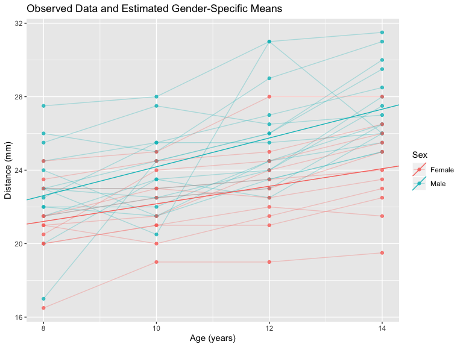

Now we look at individual-specific and mean estimated trajectories.

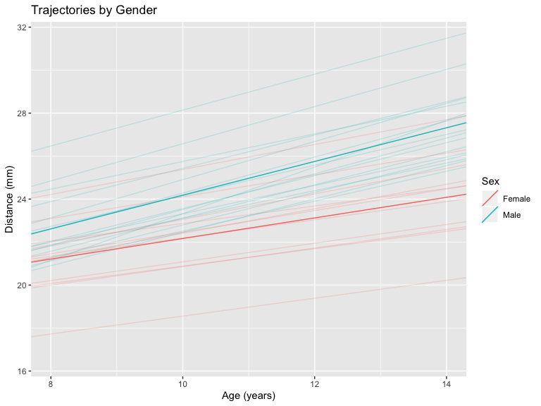

```r
boyint=coef(m1)$Subject[1:16,1]+coef(m1)$Subject[1:16,2]
girlint=coef(m1)$Subject[17:27,1]
boyslope=coef(m1)$Subject[1:16,3]+coef(m1)$Subject[1:16,4]
girlslope=coef(m1)$Subject[17:27,3]
int=c(boyint,girlint)
sl=c(boyslope,girlslope)
est2=data.frame(sl,int,
                 SEX = c(rep('Male',16),rep('Female',11)))
library(ggplot2)
ggplot(Orthodont, aes(x=age,y=distance,color=Sex,group=Subject)) +
  geom_abline(data=est2, aes(intercept=int, slope=sl, color=SEX),alpha=.2) + geom.point(alpha=0)
  geom_abline(data=est, aes(intercept=int, slope=sl, color=SEX)) +
  xlab("Age (years)") + ylab("Distance (mm)") +
  ggtitle("Trajectories by Gender")
```